# Lab 1: Introduction to R

#### 3.4.2 Matrices

A matrix is a collection of data elements arranged in a two-dimensional rectangular layout. The elements of a matrix must be of the same type of data. Matrices are commonly used in mathematics and statistics. Math matrices and R matrices are different concepts. Matrices in R are broader.

```r
ma.1 <- matrix(1:15, nrow = 5, ncol =3)
ma.1
```

```
     [,1] [,2] [,3]
[1,]    1    6   11
[2,]    2    7   12
[3,]    3    8   13
[4,]    4    9   14
[5,]    5   10   15
```

```r
ma.2 <- matrix(names, nrow = 6, ncol = 2)
ma.2
```

```
     [,1]       [,2]
[1,] "Marshall" "Pedro"
[2,] "Ruby"     "Rebecca"
[3,] "Peppa"    "Rubble"
[4,] "George"   "Ryder"
[5,] "Suzy"     "Max"
[6,] "Danny"    "Chase"
```

Since matrices are two-dimensional, to subset or select elements from a matrix using `[ ]`, you need to define row and/or column index in `[ROW, COL]`.

```r
ma.1[2, ]   # select all elements in the 2nd row of ma.1
```

```
[1]  2  7 12
```

```r
ma.1[, 2]   # select all elements in the 2nd column of ma.1
```

```
[1]  6  7  8  9 10
```

```r
ma.1[2, 2]  # select the element in row 2 and column 2 of ma.1
```

```
[1] 7
```

```r
ma.2[3, 2]  # select the element in row 3 and column 2 of ma.2
```

```
[1] "Rubble"
```

#### 3.4.3 Arrays

In R, arrays are the data objects that can store data in more than two dimensions. Data need to be the same type.

```r
array.1 <- array(1:24, dim = c(2, 3, 4))      # 2 rows * 3 columns * 4 matrices
array.1
```

```
, , 1

     [,1] [,2] [,3]
[1,]    1    3    5
[2,]    2    4    6

, , 2

     [,1] [,2] [,3]
[1,]    7    9   11
[2,]    8   10   12

, , 3

     [,1] [,2] [,3]
[1,]   13   15   17
[2,]   14   16   18

, , 4

     [,1] [,2] [,3]
[1,]   19   21   23
[2,]   20   22   24
```

#### 3.4.4 Lists

Lists are R objects that can contain multiple components of different data types, data structures, and dimensions.

```r
names
```

```
 [1] "Marshall" "Ruby"     "Peppa"    "George"   "Suzy"     "Danny"
 [7] "Pedro"    "Rebecca"  "Rubble"   "Ryder"    "Max"      "Chase"
```

```r
grades_1
```

```
 [1] 75 76 77 78 79 80 81 82 83 84
```

```r
list.1 <- list(name = names, grade = grades_1, random_num = 9)      # create a list with 3 components
list.1
```

```
$name
 [1] "Marshall" "Ruby"     "Peppa"    "George"   "Suzy"     "Danny"
 [7] "Pedro"    "Rebecca"  "Rubble"   "Ryder"    "Max"      "Chase"

$grade
 [1] 75 76 77 78 79 80 81 82 83 84

$random_num
[1] 9
```

```r
names(list.1)
```

```
[1] "name"       "grade"      "random_num"
```

To select from a list, you can keep using index numbers with square brackets `[ ]`, or you can use the extractor operator `$`.

```r
list.1[1]     # create a new list with only the 1st component from list.1
```

```
$name
 [1] "Marshall" "Ruby"     "Peppa"    "George"   "Suzy"     "Danny"
 [7] "Pedro"    "Rebecca"  "Rubble"   "Ryder"    "Max"      "Chase"
```

```r
list.1[[1]]   # extract all elements from the 1st component of list.1 (i.e. the name vector)
```

```
 [1] "Marshall" "Ruby"     "Peppa"    "George"   "Suzy"     "Danny"
 [7] "Pedro"    "Rebecca"  "Rubble"   "Ryder"    "Max"      "Chase"
```

```r
list.1$name   # extract all the elements from the component named "name" from list.1
```

```
 [1] "Marshall" "Ruby"     "Peppa"    "George"   "Suzy"     "Danny"
 [7] "Pedro"    "Rebecca"  "Rubble"   "Ryder"    "Max"      "Chase"
```

```r
list.1[[1]][1]
```

```
[1] "Marshall"
```

```r
list.1$name[1]
```

```
[1] "Marshall"
```

#### 3.4.5 Data Frames

A data frame is a list whose elements are equal-length vectors, and vectors can be different data types. Basically, a data frame is a limited version of a list, or a flexible version of a matrix. In a data frame, vectors/variables can be different types, but the length needs to be the same.

```r
df1 <- data.frame(Name = names[1:10], Grade = grades_1)
df1
```

| Name | Grade |
| --- | --- |
| Marshall | 75 |
| Ruby | 76 |
| Peppa | 77 |
| George | 78 |
| Suzy | 79 |
| Danny | 80 |
| Pedro | 81 |
| Rebecca | 82 |
| Rubble | 83 |
| Ryder | 84 |

```r
df1$Name
```

```
 [1] "Marshall" "Ruby"     "Peppa"    "George"   "Suzy"     "Danny"
 [7] "Pedro"    "Rebecca"  "Rubble"   "Ryder"
```

```r
df1$Grade[1:5]
```

```
[1] 75 76 77 78 79
```

```r
df1$Grade[df1$Grade >= 80]
```

```
[1] 80 81 82 83 84
```

```r
df1$Name[df1$Grade >= 80]
```

```
[1] "Danny"   "Pedro"   "Rebecca" "Rubble"  "Ryder"
```

```r
df1[df1$Grade >= 80, ]
```

|  | Name | Grade |
| --- | --- | --- |
| 6 | Danny | 80 |
| 7 | Pedro | 81 |
| 8 | Rebecca | 82 |
| 9 | Rubble | 83 |
| 10 | Ryder | 84 |

```r
mean(df1$Grade)
```

```
[1] 79.5
```

## 4 R Packages

To extend the capabilities of R, various packages are developed to handle different tasks: data manipulation, analysis, and visualization.

### 4.1 Base Packages

The base packages providing basic functions and datasets are pre-included with R installation. For example, the package *datasets*, which provides a collection of datasets.

- Try `data()`, which returns the list of datasets within this package.
- To load one of the listed datasets, e.g. `mtcars`, type `data(mtcars)`. This dataset provides statistics from road tests on multiple models of cars.

### 4.2 Contributed Packages

Many other contributed packages, designed to implement specific operations, are not included with R by default. To utilize these packages, we need to install and load them individually.

- Install a package, type `install.packages("tidyverse")`
- Load the installed package, type `library(tidyverse)`

**Warning**

When installing, the package names must be in quotes `" "`. When loading, they are not necessary.

After loading the package, we can use the functions in *tidyverse*. *tidyverse* is a collection of packages, such as *dplyr* and *tidyr* for data manipulation, *ggplot2* for data visualization, *lubridate* for processing time-series data.

- Example with `select` from *dplyr*, type `?select` first to see the R Documentation for this function.

  ```r
  data(mpg)     # new dataset mpg also comes with tidyverse

  head(mpg)     # head() displays the first 6 observations of a dataset
  ```

  | manufacturer | model | displ | year | cyl | trans | drv | cty | hwy | fl | class |
  | --- | --- | --- | --- | --- | --- | --- | --- | --- | --- | --- |
  | audi | a4 | 1.8 | 1999 | 4 | auto(l5) | f | 18 | 29 | p | compact |
  | audi | a4 | 1.8 | 1999 | 4 | manual(m5) | f | 21 | 29 | p | compact |
  | audi | a4 | 2.0 | 2008 | 4 | manual(m6) | f | 20 | 31 | p | compact |
  | audi | a4 | 2.0 | 2008 | 4 | auto(av) | f | 21 | 30 | p | compact |
  | audi | a4 | 2.8 | 1999 | 6 | auto(l5) | f | 16 | 26 | p | compact |
  | audi | a4 | 2.8 | 1999 | 6 | manual(m5) | f | 18 | 26 | p | compact |

  ```r
  head(select(mpg, c(manufacturer, model, year)))      # select() selects named variables from a data frame
  ```

  | manufacturer | model | year |
  | --- | --- | --- |
  | audi | a4 | 1999 |
  | audi | a4 | 1999 |
  | audi | a4 | 2008 |
  | audi | a4 | 2008 |
  | audi | a4 | 1999 |
  | audi | a4 | 1999 |

  ```r
  head(filter(mpg, year >= 2000))     # filter() subsets a data frame based on defined conditions
  ```

  | manufacturer | model | displ | year | cyl | trans | drv | cty | hwy | fl | class |
  | --- | --- | --- | --- | --- | --- | --- | --- | --- | --- | --- |
  | audi | a4 | 2.0 | 2008 | 4 | manual(m6) | f | 20 | 31 | p | compact |
  | audi | a4 | 2.0 | 2008 | 4 | auto(av) | f | 21 | 30 | p | compact |
  | audi | a4 | 3.1 | 2008 | 6 | auto(av) | f | 18 | 27 | p | compact |
  | audi | a4 quattro | 2.0 | 2008 | 4 | manual(m6) | 4 | 20 | 28 | p | compact |
  | audi | a4 quattro | 2.0 | 2008 | 4 | auto(s6) | 4 | 19 | 27 | p | compact |
  | audi | a4 quattro | 3.1 | 2008 | 6 | auto(s6) | 4 | 17 | 25 | p | compact |

  See how packages simplify the code and make it more intuitive. More details about *tidyverse* will be discussed in Lab 2.

## 5 R Script

R script is simply a text file containing a set of commands and comments, which allows you to save, edit, and execute your code. To create an R script, in the top toolbar, select `File > New File > R Script`.

[figure not shown]

The Source Pane and R Sript

**Note**

All lines entered in an R script are interpreted as code to be run by R, unless they begin with `#` (Shift + 3). Using `#` is useful for documenting and explaining your code, or for temporarily disabling sections of code.

## 6 Useful Resources

This section lists some useful resources for your exploration of R.

### 6.1 Base R Cheat Sheet

[Click here for more information](https://github.com/rstudio/cheatsheets/blob/main/base-r.pdf)

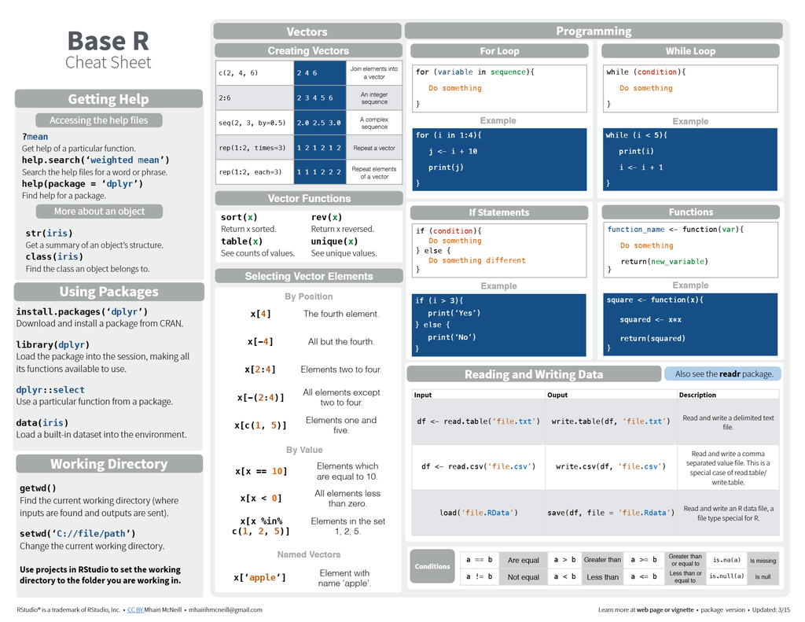

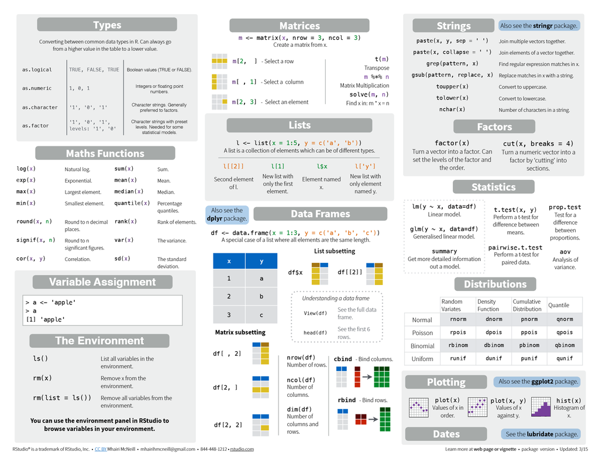

### 6.2 An Introduction to R

[An Introduction to R, by Venables, W. N., Smith, D. M., & R Development Core Team](https://cran.r-project.org/doc/manuals/r-release/R-intro.pdf)

## 7 Exercise

Load the dataset “mpg” and work through the exercises below. Note, “mpg” is included in the tidyverse package, so you will need to load the package first.

1. Calculate the **mean**, **range**, **minimum**, and **maximum** of the variable “hwy” across all models. Then, combine these statistics into one vector. (Tip: look up the RDocumentation for the functions `mean`, `range`, `min`, and `max`).
2. Since “hwy” is measured in miles per gallon, create a new variable in mpg that expresses “hwy” in litres per 100 km.
3. Identify the models of cars that are most fuel-efficient. Which classes of cars are least fuel-efficient?
4. Compute the quantiles of “hwy”. Can you also calculate the tertiles instead? (Tip: look up for the RDocumentation for the function `quantile`).
5. Now, based on the tertiles you calculated, assign “least efficient”, “medium”, and “most efficient” labels to all models. Try using both base R indexing and the function `ifelse`.